# R Notebook

# Where is this data from?

It is from the ACLED database. It is a wellknown project and it is hugh. There are some data scientists, social schientists and professors studying on project.

# Loading packages.

```r
library(tidyverse)
library(dplyr)  #Used for data manipulation of the data set
library(ggplot2) #Used for plotting
library(readr) #Used for reading files
library(lubridate)  #Used for time series
library(RColorBrewer)    #Used for color paletting in R
```

# Let’s check this data and do some cleaning.

```r
df <- read_csv("~/Downloads/2006-2012.csv")
names(df)
```

```
 [1] "X1"               "data_id"          "iso"              "event_id_cnty"    "event_id_no_cnty"
 [6] "event_date"       "year"             "time_precision"   "event_type"       "sub_event_type"
[11] "actor1"           "assoc_actor_1"    "actor2"           "assoc_actor_2"    "interaction"
[16] "region"           "country"          "admin1"           "admin2"           "admin3"
[21] "location"         "source"           "source_scale"     "notes"            "fatalities"
[26] "iso3"
```

```r
class(df)
```

```
[1] "spec_tbl_df" "tbl_df"      "tbl"         "data.frame"
```

```r
str(df)
```

```
Classes ‘spec_tbl_df’, ‘tbl_df’, ‘tbl’ and 'data.frame':    57695 obs. of  26 variables:
 $ X1              : num  1 2 3 4 5 6 7 8 9 10 ...
 $ data_id         : num  5747423 5271879 5288547 5805036 5757795 ...
 $ iso             : num  12 404 566 706 710 729 716 586 586 586 ...
 $ event_id_cnty   : chr  "ALG3168" "KEN3542" "NIG4288" "SOM10487" ...
 $ event_id_no_cnty: num  3168 3542 4288 10487 3380 ...
 $ event_date      : chr  "31-Dec-12" "31-Dec-12" "31-Dec-12" "31-Dec-12" ...
 $ year            : num  2012 2012 2012 2012 2012 ...
 $ time_precision  : num  1 1 1 1 1 1 1 1 1 1 ...
 $ event_type      : chr  "Protests" "Violence against civilians" "Riots" "Riots" ...
 $ sub_event_type  : chr  "Peaceful protest" "Attack" "Violent demonstration" "Violent demonstration" ...
 $ actor1          : chr  "Protesters (Algeria)" "Mungiki Militia" "Rioters (Nigeria)" "Rioters (Somalia)" ...
 $ assoc_actor_1   : chr  NA NA NA NA ...
 $ actor2          : chr  NA "Civilians (Kenya)" "Military Forces of Nigeria (1999-2015)" "Rioters (Somalia)" ...
 $ assoc_actor_2   : chr  NA NA NA NA ...
 $ interaction     : num  60 37 15 55 57 27 60 60 60 60 ...
 $ region          : chr  "Northern Africa" "Eastern Africa" "Western Africa" "Eastern Africa" ...
 $ country         : chr  "Algeria" "Kenya" "Nigeria" "Somalia" ...
 $ admin1          : chr  "Ouargla" "Nyeri" "Plateau" "Awdal" ...
 $ admin2          : chr  "Ouargla" "Nyeri Town" "Jos South" "Borama" ...
 $ admin3          : chr  NA "Rware" NA NA ...
 $ location        : chr  "Ouargla" "Nyeri" "Barakin Kuru Baba" "Borama" ...
 $ source          : chr  "Al Jazeera" "Star (Kenya)" "Daily Leadership (Nigeria)" "Local Source" ...
 $ source_scale    : chr  "National" "National" "Subnational" "Other" ...
 $ notes           : chr  "Unemployed continue protests in Algerias southern region of Ouargla" "Mungiki sect adherents beat local youth who were not a part of the militia" "Youths and police clashed in Kuru, near Jos, following the killing of one youth on Sunday night by a stray bull"| __truncated_…
 $ fatalities      : num  0 0 7 1 0 0 0 0 0 0 ...
 $ iso3            : chr  "DZA" "KEN" "NGA" "SOM" ...
 - attr(*, "spec")=
  .. cols(
  ..   X1 = col_double(),
  ..   data_id = col_double(),
  ..   iso = col_double(),
  ..   event_id_cnty = col_character(),
  ..   event_id_no_cnty = col_double(),
  ..   event_date = col_character(),
  ..   year = col_double(),
  ..   time_precision = col_double(),
  ..   event_type = col_character(),
  ..   sub_event_type = col_character(),
  ..   actor1 = col_character(),
  ..   assoc_actor_1 = col_character(),
  ..   actor2 = col_character(),
  ..   assoc_actor_2 = col_character(),
  ..   interaction = col_double(),
  ..   region = col_character(),
  ..   country = col_character(),
  ..   admin1 = col_character(),
  ..   admin2 = col_character(),
  ..   admin3 = col_character(),
  ..   location = col_character(),
  ..   source = col_character(),
  ..   source_scale = col_character(),
  ..   notes = col_character(),
  ..   fatalities = col_double(),
  ..   iso3 = col_character()
  .. )
```

#I want to remove some columns which only for data entry

| X1 | event_date | year | event_type | sub_event_type | actor1 | actor2 | interaction | region | country | admin1 | admin2 | admin3 | location | source | source_scale | notes | fatalities | MONTH |
| --- | --- | --- | --- | --- | --- | --- | --- | --- | --- | --- | --- | --- | --- | --- | --- | --- | --- | --- |
| 1 | 2012-12-31 | 2012 | Protests | Peaceful protest | Protesters (Algeria) | NONE | 60 | Northern Africa | Algeria | Ouargla | Ouargla | NA | Ouargla | Al Jazeera | National | Unemployed continue protests in Algerias southern region of Ouargla | 0 | 12 |
| 2 | 2012-12-31 | 2012 | Violence against civilians | Attack | Mungiki Militia | Civilians (Kenya) | 37 | Eastern Africa | Kenya | Nyeri | Nyeri Town | Rware | Nyeri | Star (Kenya) | National | Mungiki sect adherents beat local youth who were not a part of the militia | 0 | 12 |
| 3 | 2012-12-31 | 2012 | Riots | Violent demonstration | Rioters (Nigeria) | Military Forces of Nigeria (1999-2015) | 15 | Western Africa | Nigeria | Plateau | Jos South | NA | Barakin Kuru Baba | Daily Leadership (Nigeria) | Subnational | Youths and police clashed in Kuru, near Jos, following the killing of one youth on Sunday night by a stray bullet. The youths took the streets in protest of the killing by setting large fires in the s… | 7 | 12 |
| 4 | 2012-12-31 | 2012 | Riots | Violent demonstration | Rioters (Somalia) | Rioters (Somalia) | 55 | Eastern Africa | Somalia | Awdal | Borama | NA | Borama | Local Source | Other | One person was killed and eight others injured after violent protests against the outcome of the local elections erupted in Borama on 30/12. The army was deployed to put the situation under control, b… | 1 | 12 |
| 5 | 2012-12-31 | 2012 | Riots | Mob violence | Rioters (South Africa) | Civilians (South Africa) | 57 | Southern Africa | South Africa | Western Cape | City of Cape Town | City of Cape Town | Parkwood | Cape Argus | National | Residents protest and attack man they believed was responsible for murdering local girl. It was later discovered that the mob attacked an innocent man | 0 | 12 |
| 6 | 2012-12-31 | 2012 | Violence against civilians | Attack | JEM: Justice and Equality Movement | Civilians (Sudan) | 27 | Northern Africa | Sudan | North Darfur | Ailliet | NA | El Taweisha | Radio Dabanga | National | JEM rebels rob civilians in Al Tawisha market | 0 | 12 |

```r
df1%>%
  group_by(country)%>%
  summarise(sum(fatalities))%>%
  arrange(desc(`sum(fatalities)`))%>%
  head(10)
```

| country | sum(fatalities) |
| --- | --- |
| Sudan | 16231 |
| Democratic Republic of Congo | 13221 |
| Somalia | 12118 |
| Pakistan | 9669 |
| Nigeria | 8736 |
| Ethiopia | 7225 |
| South Sudan | 6740 |
| Libya | 3975 |
| Kenya | 3390 |
| Chad | 3389 |

#We see that Sudan has the largest number of fatalities in all other the countries from year 2006 t0 2012.

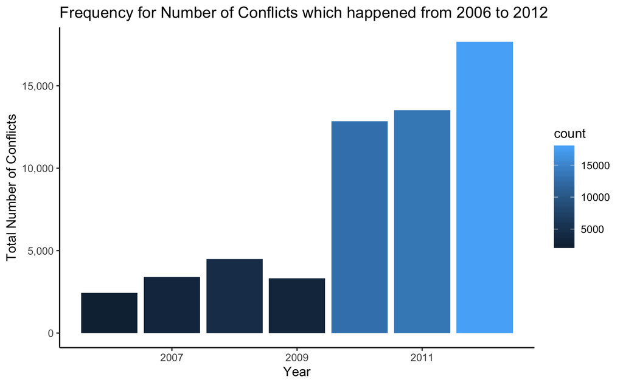

#From this graph, we can see these is a decrese in 2009 and it jumped dramatically since 2010. And the total number of conflicts keeped increasing. We want to look further on the data of 2012 since it is the closest year from now.

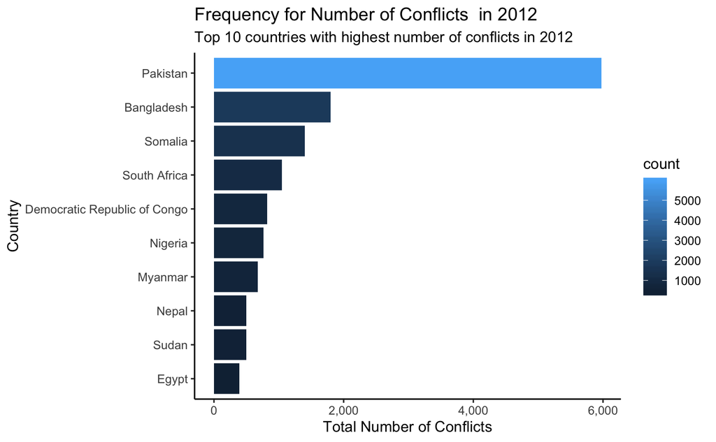

```r
#creating data set for ggplot()
plot1 <- df1 %>%
  dplyr::filter(year == 2012)%>%
  group_by(country)%>%
  summarise(count=n())%>%
  arrange(desc(count))%>%
  head(10)


  #using ggplot for visualization
plot1 %>%
  arrange(desc(count))%>%
  ggplot(aes(x = reorder(country,count), y=count,fill=count)) +
  geom_bar(stat = "identity") +
  scale_x_discrete(name = "Country") +
  scale_y_continuous(name = "Total Number of Conflicts",labels = scales::comma) +
  ggtitle("Frequency for Number of Conflicts  in 2012",
  subtitle = "Top 10 countries with highest number of conflicts in 2012")+
  coord_flip()
```

## As shown, Pakistan is outstandingly observed as the one who has the largest number of conflicts.

## I am interested in investigating the trend of fatalities

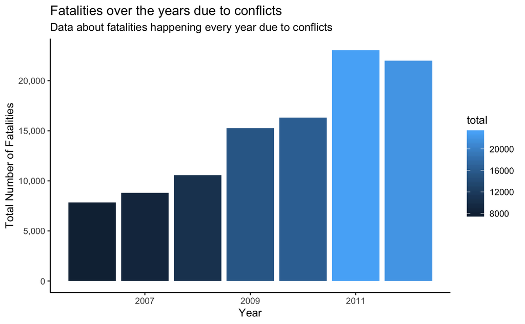

```r
df1 %>%
  group_by(year)%>%
  summarise(total=sum(fatalities))%>%
  ggplot(aes(x=year,y=total,fill=total))+
  geom_bar(stat = "identity")+
  scale_x_continuous(name = "Year") +
  scale_y_continuous(name = "Total Number of Fatalities",labels = scales::comma) +
  ggtitle("Fatalities over the years due to conflicts",
  subtitle = "Data about fatalities happening every year due to conflicts")
```

## This is really a huge data set. And a lot of things can be tested and evaluated from it. I basically used ggplot tool to draw several graphs with the stats I am most interested in. With the given data, I found: 1)Sudan has the largest number of fatalities in all other the countries from year 2006 t0 2012. 2) These is a decrese in 2009 and it jumped dramatically since 2010. And the total number of conflicts keeped increasing. 3)And I dived into the data of 2012, I sadly found that Pakistan is outstandingly observed as the one who has the largest number of conflicts.